# Recitation 5

##### Change the column names for easy access

```r
# Print the columns of df so I know what I am looking for
colnames(df)
```

```
 [1] ".id"
 [2] "Utility ID"
 [3] "Utility Name"
 [4] "Plant Code"
 [5] "Plant Name"
 [6] "State"
 [7] "County"
 [8] "Generator ID"
 [9] "Technology"
[10] "Prime Mover"
[11] "Unit Code"
[12] "Ownership"
[13] "Duct Burners"
[14] "Can Bypass Heat Recovery Steam Generator?"
[15] "RTO/ISO LMP Node Designation"
```

[output cut: 61 more lines]

```r
# Rename these for easy access
df[,upyear := `Operating Year`]
df[,downyear := `Retirement Year`]
df[,capacity :=`Nameplate Capacity (MW)`]
```

##### Get a sum of new and retiring capacity year on year (new variable) by technology

```r
# Set a 'key' for df
# In response to Gabriel's question, I don't explicitly actually use this line
# But I will set keys later that I do use!
setkey(df, upyear, Technology)
# View the key - this is just a list of columns for easy access.
key(df)
```

```
[1] "upyear"     "Technology"
```

```r
# One-line data.table query. by parameter:
# i = choose only the rows which have we have a year for which they come online
# j = create a column called year which is equal to upyear (this is to join with subtract later), and a column called 'capacity additions' which is the sum of capacities.
# by = I don't want to sum across the whole dataset for capacities, I only want to do so in groups, which is the operating year-technology pair.
add <- df[!is.na(upyear),.(year = upyear,capacity_additions = sum(capacity,na.rm = T)), by = .(upyear, Technology)]
# Same code, I could have done the same thing using the key
add <- df[!is.na(upyear),.(year = upyear,capacity_additions = sum(capacity,na.rm = T)), by = key(df)]
# Same as making add, only I'm grouping the power plants by the years they come offline rather than online.
subtract <-  df[!is.na(downyear),.(year = downyear,capacity_subtractions = sum(capacity,na.rm = T)), by = .(downyear, Technology)]
# view em
add
```

| upyear | Technology | year | capacity_additions |
| --- | --- | --- | --- |
| 1891 | Conventional Hydroelectric | 1891 | 3.9 |
| 1893 | Conventional Hydroelectric | 1893 | 0.8 |
| 1896 | Conventional Hydroelectric | 1896 | 4.8 |
| 1898 | Conventional Hydroelectric | 1898 | 6.0 |
| 1899 | Conventional Hydroelectric | 1899 | 3.2 |
| 1900 | Conventional Hydroelectric | 1900 | 9.2 |
| 1901 | Conventional Hydroelectric | 1901 | 4.3 |
| 1902 | Conventional Hydroelectric | 1902 | 2.4 |
| 1903 | Conventional Hydroelectric | 1903 | 45.6 |
| 1904 | Conventional Hydroelectric | 1904 | 29.6 |

[output cut: 990 more lines]

```r
subtract
```

| downyear | Technology | year | capacity_subtractions |
| --- | --- | --- | --- |
| 1999 | Conventional Hydroelectric | 1999 | 0.4 |
| 2006 | Conventional Hydroelectric | 2006 | 26.5 |
| 2013 | Conventional Hydroelectric | 2013 | 154.7 |
| 2018 | Conventional Hydroelectric | 2018 | 48.3 |
| 2010 | Conventional Hydroelectric | 2010 | 124.0 |
| 1984 | Conventional Hydroelectric | 1984 | 0.9 |
| 2017 | Conventional Hydroelectric | 2017 | 111.1 |
| 2019 | Conventional Hydroelectric | 2019 | 147.2 |
| 2007 | Conventional Hydroelectric | 2007 | 13.7 |
| 2012 | Conventional Hydroelectric | 2012 | 307.3 |

[output cut: 302 more lines]

##### Join the additions and subtractions

```r
## Use expand_grid to make sure that there's a key for every year
## (this is easy to overlook until you plot)
## The purpose of this is so you don't have NAs in your dataset - I want solar in 1893 to be 0, not NA, but this wouldn't be given by the add or subtract data.tables.
# check ?expand_grid
# This is called an 'index' or 'key'
cap <- as.data.table(expand_grid('year' = min(add[,year]):max(add[,year]), 'Technology' = unique(add[,Technology])))
## Check out what this looks like
head(cap)
```

| year | Technology |
| --- | --- |
| 1891 | Conventional Hydroelectric |
| 1891 | Natural Gas Internal Combustion Engine |
| 1891 | Conventional Steam Coal |
| 1891 | Petroleum Liquids |
| 1891 | Natural Gas Steam Turbine |
| 1891 | Other Gases |

```r
tail(cap)
```

| year | Technology |
| --- | --- |
| 2019 | Natural Gas with Compressed Air Storage |
| 2019 | Coal Integrated Gasification Combined Cycle |
| 2019 | Batteries |
| 2019 | Flywheels |
| 2019 | Solar Thermal with Energy Storage |
| 2019 | Offshore Wind Turbine |

```r
# The purpose of the key is so that things can join later. Merges and Joins in data,table require that keys are the same so it knows which rows correspond to which other rows in two different datasets.
## Set keys - note that it's year-Technology now so that the two tables match, instead of operating_year-technology and retirement_year-technology pairs.
setkey(add, year, Technology)
setkey(subtract, year, Technology)
# Set the key to be the same as (capacity) additions and subtractions above
setkey(cap, year, Technology)
## Sense check - this commented-out code was for an early version of the dataset where there were some 0s in operating year
# add <- add[upyear !=0]
## Use expand_grid to make sure that there's a key for every year
## (this is easy to overlook until you plot)
# cap <- as.data.table(expand_grid('year' = min(add[,year]):max(add[,year]), 'Technology' = unique(add[,Technology])))
# setkey(cap, year, Technology)
## now merge in the additions and subtractions
# I'm merging the additions and subtractions, all and all.x is equivalent to an outer join which means I keep ALL rows across the two tables. If I didn't do this I'd get back only those columns for which a technology-year pair had both power plants retiring and coming online.
add_subtract <-merge(add, subtract, all = TRUE)
# now I'm merging them with the index that I've defined. I'm doing a left-join here with all.x = TRUE, which means I only want to keep the index of the left dataset (my first parameter, in this case cap). This means that any rows in add_subtract without a corresponding index in the key of cap would be discarded.
cap <-  merge(cap, add_subtract,all.x = TRUE)
# View the top 50 rows. There's a lot of NAs since many technologies did not exist in 1891.
head(cap,50)
```

| year | Technology | upyear | capacity_additions | downyear | capacity_subtractions |
| --- | --- | --- | --- | --- | --- |
| 1891 | All Other | NA | NA | NA | NA |
| 1891 | Batteries | NA | NA | NA | NA |
| 1891 | Coal Integrated Gasification Combined Cycle | NA | NA | NA | NA |
| 1891 | Conventional Hydroelectric | 1891 | 3.9 | NA | NA |
| 1891 | Conventional Steam Coal | NA | NA | NA | NA |
| 1891 | Flywheels | NA | NA | NA | NA |
| 1891 | Geothermal | NA | NA | NA | NA |
| 1891 | Hydroelectric Pumped Storage | NA | NA | NA | NA |
| 1891 | Landfill Gas | NA | NA | NA | NA |
| 1891 | Municipal Solid Waste | NA | NA | NA | NA |

[output cut: 40 more lines]

#### Plot total capacity over time. How has this changed?

Total capacity grows over time a lot! It seems to follow an S-curve until the year 2000 from 0 to 800GW, and then jumps up again by 1.5x.

```r
## So if there were no additions or subtractions in a year of a technology, set to 0.
cap[is.na(capacity_additions), capacity_additions:= 0]
cap[is.na(capacity_subtractions), capacity_subtractions:= 0]
# Calculate the net capacity change = additions - subtractions
cap_final <- cap[,.(net_capacity_change = capacity_additions-capacity_subtractions), by = key(cap)]
# Take a cumulatie sum over the years by technology.  Note here that because year is the first value of my key, the cumulative sum knows to sum over it.
cap_final[, capacity := cumsum(net_capacity_change), by = Technology]
cap_final
```

| year | Technology | net_capacity_change | capacity |
| --- | --- | --- | --- |
| 1891 | All Other | 0.0 | 0.0 |
| 1891 | Batteries | 0.0 | 0.0 |
| 1891 | Coal Integrated Gasification Combined Cycle | 0.0 | 0.0 |
| 1891 | Conventional Hydroelectric | 3.9 | 3.9 |
| 1891 | Conventional Steam Coal | 0.0 | 0.0 |
| 1891 | Flywheels | 0.0 | 0.0 |
| 1891 | Geothermal | 0.0 | 0.0 |
| 1891 | Hydroelectric Pumped Storage | 0.0 | 0.0 |
| 1891 | Landfill Gas | 0.0 | 0.0 |
| 1891 | Municipal Solid Waste | 0.0 | 0.0 |

[output cut: 990 more lines]

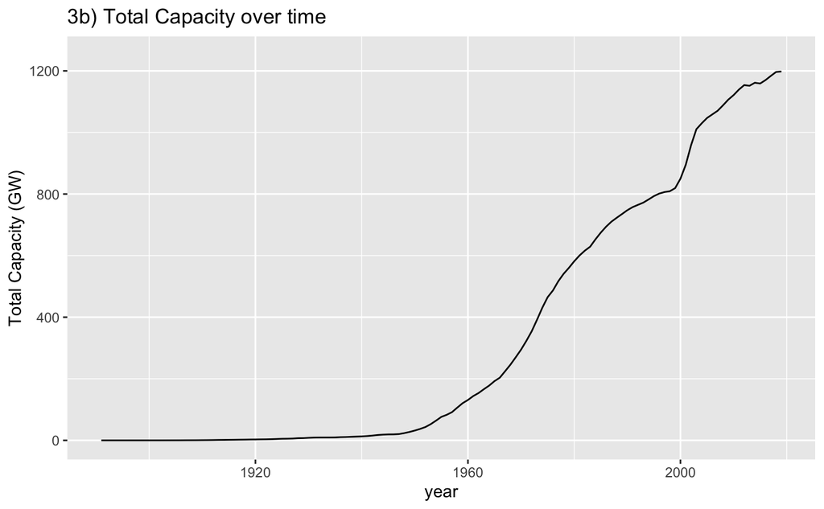

```r
cap_total <-  cap_final[, .(total_capacity = sum(capacity)), year ]
ggplot(cap_total, aes(x = year, y = `total_capacity`/1000)) +
  geom_line() +
  scale_y_continuous(name = "Total Capacity (GW)", limits = c(0,1250)) +
  ggtitle("3b) Total Capacity over time")
```

```r
tail(cap_total)
```

| year | total_capacity |
| --- | --- |
| 2014 | 1161409 |
| 2015 | 1158891 |
| 2016 | 1169922 |
| 2017 | 1183497 |
| 2018 | 1196421 |
| 2019 | 1197924 |

#### Plot the share of capacity from the different sources over time. How has this changed?

In the next 3 code blocks I spend a bunch of time matching colors to different fuels and aggregating the technologies to form less granular, more high-level groups. This wasn’t necessary, but it was good to make the colors intuitive for a reader.

It was not necessary to filter the dataset to 1973 until the last step, but it tells an exciting story if you don’t! In the pre 1910s, everything was hydroelectric. Then fossil fuels took off in the 1940s, and nuclear followed in the 1960s. If you take the stacked bar graph as a proportion, the minimum renewable % seems to have been in about 2005 which is surprising! and wind and solar only started recently, now together comprising about 10% of capacity. Most peole won’t know off the top of their head what [combined cycle](https://en.wikipedia.org/wiki/Combined_cycle_power_plant) is - so if they explained this this was good!

```r
# Change tech to a factor so that categories work for plotting
cap_final[,Technology:= as.factor(Technology)]
# view it
tail(cap_final)
```

| year | Technology | net_capacity_change | capacity |
| --- | --- | --- | --- |
| 2019 | Petroleum Coke | -67.0 | 1638.7 |
| 2019 | Petroleum Liquids | -307.5 | 34481.3 |
| 2019 | Solar Photovoltaic | 5480.7 | 36020.4 |
| 2019 | Solar Thermal with Energy Storage | 0.0 | 405.0 |
| 2019 | Solar Thermal without Energy Storage | 0.0 | 1369.6 |
| 2019 | Wood/Wood Waste Biomass | -421.0 | 9519.1 |

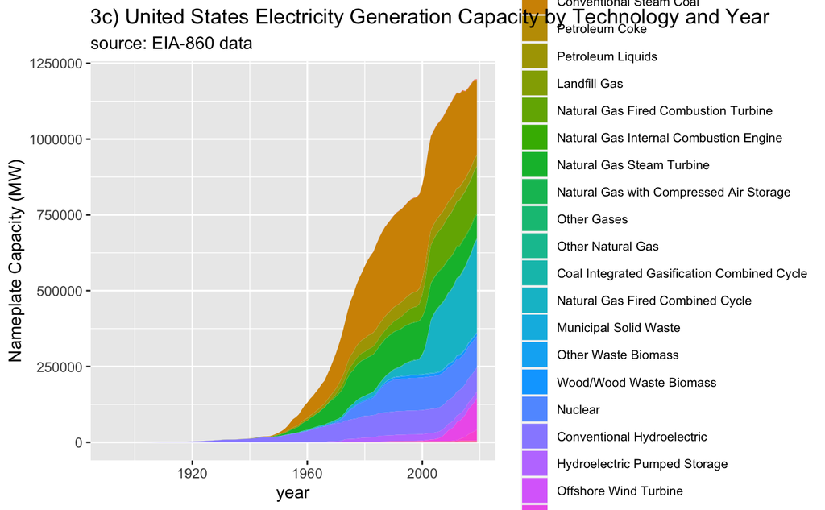

```r
# Set colors to use for plotting graphs
## Set high level groups
color_key = list('other' = 'coral',
                 "coal" = "chocolate4",
                 'petroleum' = "black",
                 'gas' = "gray79",
                 'combined cycle' = 'gray22',
                 'waste' = 'red4',
                 'nuclear' = 'lightgoldenrod',
                 'hydro' = 'cornflowerblue',
                 'wind' = 'aliceblue',
                 'solar' = 'gold',
                 'geothermal' = 'brown2'
                 )
## Get a list of technologies
techs <-  unique(cap_final$Technology)
## Make a hash lookup for the set of 27 techs
colors <-  rep('coral', length(techs))
colors <-  setNames(colors, techs)
## Aggregate by types
cap_final[, tech := "other"]
cap_final[, color := "coral"]
## loop through the big categories and search for them in the technologies.
for (fuel in names(color_key)){
  # Make a second key for the 27 techs
  colors[grep(fuel,techs,ignore.case = TRUE)] = color_key[fuel]
  # add a column with the 10 techs
  cap_final[grep(fuel,Technology,ignore.case = TRUE), tech:=fuel]
  # add a column for the color
  cap_final[grep(fuel,Technology,ignore.case = TRUE), color:=color_key[fuel]]
}
# change tech to a factor(categories)
cap_final[,tech:= as.factor(tech)]
# reorder in order of pollution levels
cap_final[,tech := factor(cap_final[,tech],levels = names(color_key))]
# Change tech also to a factor
cap_final[,Technology:= as.factor(Technology)]
# Make a lookup from tech group to technology
key <-  unique(cap_final[,.(tech,Technology)])
setkey(key, tech)
# Change data types to factors then reset key
cap_final[,Technology := factor(cap_final[,Technology],levels = key[,Technology])]
cap_final[,color:= as.factor(color)]
setkey(cap_final, tech, Technology, year)
# Aggregate on the Technologies to small techs
cap_agg = cap_final[,.(capacity = sum(capacity)), , .(tech,year, color)]
# Unaggregated Technology stacked area chart
ggplot(cap_final, aes(x = year, y= capacity, fill = Technology)) +
  geom_area(position = 'stack') +
  theme(legend.text = element_text(size = 8)) +
  guides(fill = guide_legend(ncol = 1)) +
  ylab("Nameplate Capacity (MW)") +
  ggtitle("3c) United States Electricity Generation Capacity by Technology and Year", subtitle = "source: EIA-860 data")
  # scale_fill_manual(values = colors)
ggsave(file.path(output_folder, 'stacked_capacity_all.pdf'), width = 16, height = 9)
```

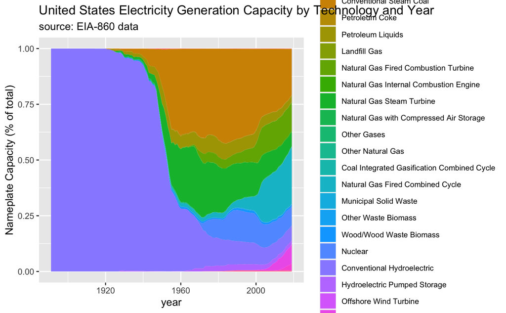

```r
# Unaggregated Technology stacked area chart as a proportion of total capacity
ggplot(cap_final, aes(x = year, y= capacity, fill = Technology)) +
  geom_area(position = 'fill') +
  theme(legend.text = element_text(size = 8)) +
  guides(fill = guide_legend(ncol = 1)) +
  ylab("Nameplate Capacity (% of total)") +
  ggtitle("United States Electricity Generation Capacity by Technology and Year", subtitle = "source: EIA-860 data")
  # scale_fill_manual(values = colors) +
ggsave(file.path(output_folder, 'proportion_capacity_all.pdf'), width = 16, height = 9)
```

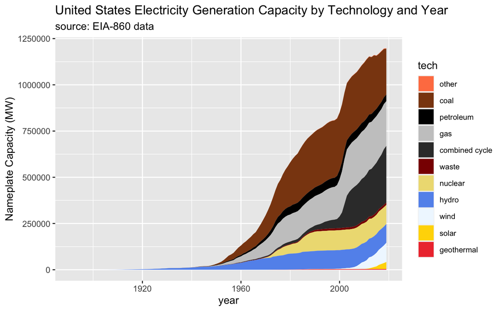

```r
# Aggregated Technology - color codedd
ggplot(cap_agg, aes(x = year, y= capacity, fill = tech)) +
  geom_area(position = 'stack') +
  theme(legend.text = element_text(size = 8)) +
  guides(fill = guide_legend(ncol = 1)) +
  ylab("Nameplate Capacity (MW)") +
  ggtitle("United States Electricity Generation Capacity by Technology and Year", subtitle = "source: EIA-860 data") +
  scale_fill_manual(values = color_key)
ggsave(file.path(output_folder, 'stacked_capacity_agg.pdf'), width = 16, height = 9)
```

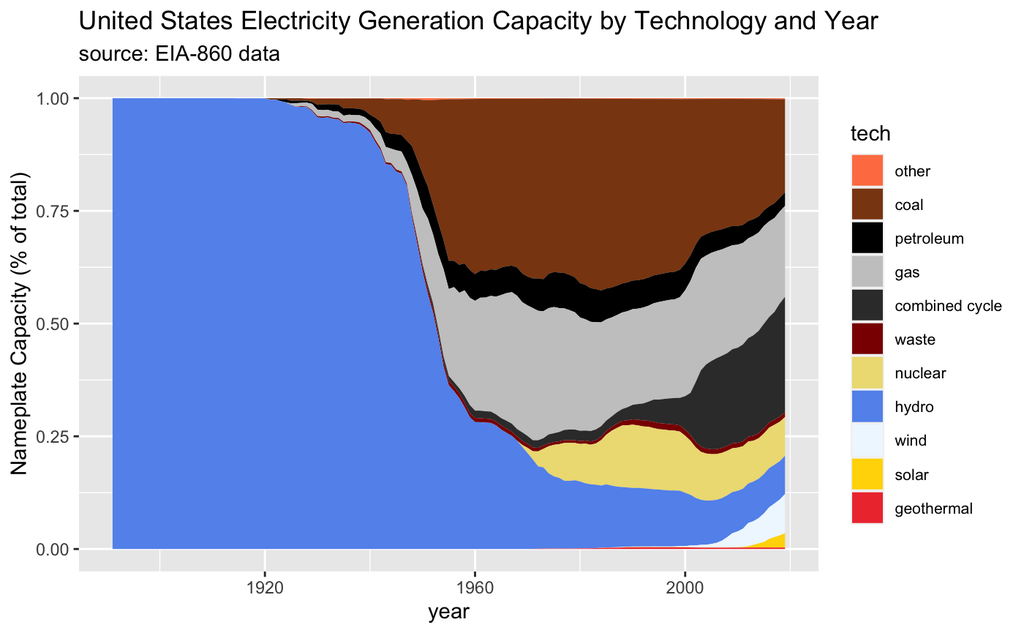

```r
# Aggregated Technology as % - color coded
ggplot(cap_agg, aes(x = year, y= capacity, fill = tech)) +
  geom_area(position = 'fill') +
  theme(legend.text = element_text(size = 8)) +
  guides(fill = guide_legend(ncol = 1)) +
  scale_fill_manual(values = color_key) +
  ylab("Nameplate Capacity (% of total)") +
  ggtitle("United States Electricity Generation Capacity by Technology and Year", subtitle = "source: EIA-860 data")
ggsave(file.path(output_folder, 'proportion_capacity_agg.pdf'), width = 16, height = 9)
```

#### Add total carbon emissions to the graph. Is there any correlation?

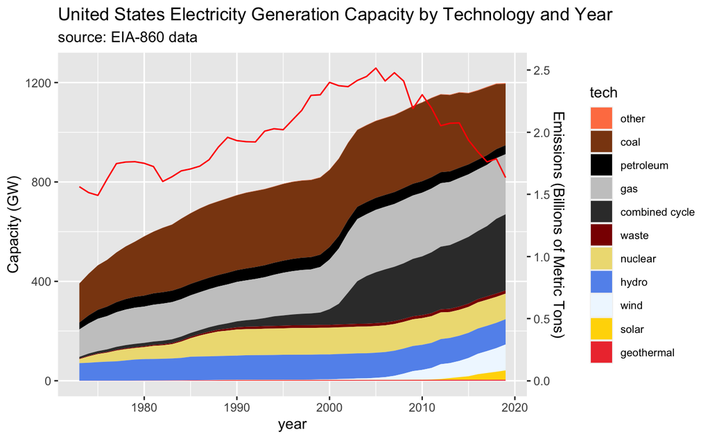

### Question 4

Suppose you are interested in the causal effect of coal capacity on carbon emissions and you want to use the dataset you just build to estimate it.

#### Run a regression of carbon emissions on coal capacity and present your results using the stargazer package. Use robust standard errors.

This should be straightforward - filter, merge, and then run the regression.

```r
# First we need to join the two datasets
coal <- cap_agg[tech == "coal"]
# Setting the key means it knows which rows to merge
setkey(coal, year)
#
coal <- merge(coal, em_total)
# Make the fit the base r way
fit_1 <- lm(`Total Emissions` ~ capacity, data = coal)
# use starprep (from the estimatr library) to uses lm_robust defaults for standard errors (robust HC2 SEs are the default in both lm_robust).
# See https://declaredesign.org/r/estimatr/articles/regression-tables.html#stargazer
lm_robust(`Total Emissions` ~ capacity, data = coal)
```

```
               Estimate   Std. Error  t value     Pr(>|t|)     CI Lower     CI Upper DF
(Intercept) 5.56559e+02 1.504316e+02 3.699749 5.854190e-04 2.535743e+02 8.595437e+02 45
capacity    5.10658e-03 5.522671e-04 9.246576 5.703112e-12 3.994257e-03 6.218903e-03 45
```

```r
# Then compare the two regressions.
stargazer(fit_1, se = starprep(fit_1), type = 'text')
```

```
length of NULL cannot be changedlength of NULL cannot be changedlength of NULL cannot be changedlength of NULL cannot be changed
```

```
===============================================
                        Dependent variable:
                    ---------------------------
                         `Total Emissions`
-----------------------------------------------
capacity                     0.005***
                              (0.001)

Constant                    556.559***
                             (150.432)

-----------------------------------------------
Observations                    47
R2                             0.566
Adjusted R2                    0.556
Residual Std. Error      198.178 (df = 45)
F Statistic           58.666*** (df = 1; 45)
===============================================
Note:               *p<0.1; **p<0.05; ***p<0.01
```

#### Does the previous regression capture the causal effect of coal capacity on carbon emissions? Why? If there is bias, do you expected to go in a particular direction? Explain.

We do expect to see the effect of coal capacity on emissions, because we understand a causal mechanism through which capacity affects emissions - through generation. So the regression captures some causal effect. The explanation of causality requires a mechanism, just because it’s biased does not mean it’s not causal.

On the other hand, *identification of the causal effect* does depend on bias. We call this ‘establishing causality’. In this case, we have a bunch of other fuels which bias the result - other fuels like natural gas also produces emissions, and these also increase total emissions. This means that the coefficient is upward biased (it is too high!).

#### Are there any controls you could add to correct this problem? Explain. You don’t have to run more regressions, just to discuss how you would do it assuming you had access to typically available data.

You could add a controls for all of the other fuels, fuel prices, demand etc for things that affect coal generation.